# Lecture3. Збір, очистка даних. Попередній аналіз.

September 21, 2019

## Опис загального процесу машинного навчання

Загальний цикл процесу виглядає так:

1. Формулювання питання і його уточнення.
2. Збір і очистка даних.
3. Попереднє дослідження даних.
4. Побудова моделі
5. Навчання моделі
6. Інтерпретація і оцінка результатів
7. Повернення до п.1.

## Основні етапи. Збір даних.

Збір даних є критично важливим для усього процесу. Без якісних, очищених даних будь-які алгоритми не мають ніякої цінності. Тому для цього етапу слід відводити досить багато часу і чітко описати структуру наявних даних, їх джерела, якість і чистоту.

## Основні етапи. Дослідження

Попереднє дослідження даних створює підгрунтя для наступної аналітики. Перший етап полягає у детальному дослідженні можливих областей значень, прихованих залежностей, помилок і пропущених даних, статистичних характеристик і т.д.

## Основні етапи. Побудова моделі

Яу вважають автори книги "Machine Learning Using R" більшість проектів з машинного навчання зупиняється на 1-2 фазі. Однак, якщо вони дійшли до етапу 3, у них є хороший шанс дійти до продукту. На цьому етапу відбувається дослідження можливих алгоритмів МН та обгрунтування доцільності їх використання.

В нормальній бізнес-моделі для отримання схвалення на використання методів МН потрібно обчислення РОІ, час, гроші і т.д.

Іноді використання МН є надмірним, достатно простої описової статистичної моделі.

## Основні етапи. Валідація

Цей етап визначає наскільки все вийшло і чи не час все викинути і почати спочатку? Іноді такі кола трапляються, оскільки складність процесів і даних обумовлює складність вирішення. А МН є такою "чарівною паличкою", використання якої говорить, що ви не розумієте дані або проблему. Дуже малоймовірним є побудова моделі МН з першої ітерації.

## Типи питань

1. Описові. Описують певну характеристику даних. Відсоток чоловіків у ВР.
2. Дослідницькі. Шукають тренди, приховані залежності і шаблони. Кількість чоловіків у ВР зменшується чи ні? Генеруються і потім перевіряються гіпотези.
3. Inferential. Переформульовують гіпотезу у вигляді питання, відповісти на яке можливо лише з залученням додаткових даних. В Україні кількість чоловіків на керівних посадах (у владі) зростає чи ні?
4. Прогнозні. Задають модель передбачення.
5. Каузальні. Чи щось залежить від чогось.

## Вернемось до депутатів

План дослідження:

1. Питання можуть бути різні 1.1. Чи змінилось щось у віковому, майновому, освітньому і т.д. вимірах за ці майже 30 років? 1.2. Скільки Саш і Вов буде в наступному скликанні? 1.3. Чи є паттерни голосувань і як вони змінювались (які політичні події впливали)? 1.4. Чи можна виділити кластери депутатів на основі їх поведінки (голосувань)?

Питання має бути не очевидне.

## Отримання даних. Пряме звернення до csv

Перший варіант:

```r
data <- read.csv('https://data.rada.gov.ua/ogd/mps/skl1/mps01-data.csv')
```

Другий варіант:

```r
library (RCurl)
download <- getURL("https://data.rada.gov.ua/ogd/mps/skl1/mps01-data.csv")
data2 <- read.csv (text = download)
```

## Отримання даних. Пряме звернення до JSON

```r
library(jsonlite)
json_file <- "https://data.rada.gov.ua/ogd/mps/skl1/mps01-data.json"
data3 <- fromJSON(json_file)
```

## Функція str()

Дуже корисна функція для швидкого аналізу структури даних

```r
class(data)
```

```
## [1] "data.frame"
```

```r
str(data)
```

```
## 'data.frame':    475 obs. of  30 variables:
##  $ id              : int  100101 101001 110001 110101 110201 110301 110401 110501 110601 110701 ...
##  $ nreg            : Factor w/ 475 levels "mp-d1_skl1","mp-d10_skl1",..: 1 2 3 4 5 6 7 8 9 10 ...
##  $ convocation     : int  1 1 1 1 1 1 1 1 1 1 ...
##  $ full_name       : Factor w/ 475 levels "Алтунян Генріх Ованесович",..: 376 205 441 230 281 395 256 373 330 215 ...
##  $ first_name      : Factor w/ 79 levels "Альберт","Анатолій",..: 38 20 31 20 50 13 20 50 37 59 ...
##  $ second_name     : Factor w/ 90 levels "Адамович","Анатолійович",..: 66 69 72 27 23 12 60 70 39 33 ...
##  $ last_name       : Factor w/ 449 levels "Алтунян","Ананьєв",..: 355 193 418 218 263 374 240 352 311 203 ...
##  $ short_name      : Factor w/ 167 levels "А.А.","А.Б.",..: 94 38 65 29 100 27 37 105 84 129 ...
##  $ other_name      : Factor w/ 8 levels "","Булига","Віктор",..: 1 1 1 1 1 1 1 1 1 1 ...
##  $ date_begin      : Factor w/ 12 levels "04.01.1992","04.05.1993",..: 7 7 7 7 7 7 7 7 7 7 ...
##  $ date_end        : Factor w/ 14 levels "01.01.1992","04.01.1992",..: 5 5 5 10 5 5 5 5 5 10 ...
##  $ district_text   : Factor w/ 453 levels "Алуштинський виборчий округ № 243, Республіка Крим",..: 9 237 49 56 290 307 319 372 419 444 ...
##  $ district_name   : Factor w/ 451 levels "Алуштинський виборчий округ № 243",..: 9 235 49 56 288 305 317 370 417 442 ...
##  $ district_num    : int  1 10 100 101 102 103 104 105 106 107 ...
```

[output cut: 16 more lines]

## Функція table()

Знаходить дублікати, обчислює кількість входжень. Можна знайти відсоток або долю.

```r
head(sort(table(data$first_name),decreasing = T),3)
```

```
##
## Володимир    Микола Олександр
##        62        40        36
```

## Питання: Як змінювались найпоширеніші імена серед депутатів?

Зчитаємо інформацію про всіх депутатів всіх скликань.

```r
data_1 <- read.csv('https://data.rada.gov.ua/ogd/mps/skl1/mps01-data.csv')
data_2 <- read.csv('https://data.rada.gov.ua/ogd/mps/skl2/mps02-data.csv')
data_3 <- read.csv('https://data.rada.gov.ua/ogd/mps/skl3/mps03-data.csv')
data_4 <- read.csv('https://data.rada.gov.ua/ogd/mps/skl4/mps04-data.csv')
data_5 <- read.csv('https://data.rada.gov.ua/ogd/mps/skl5/mps05-data.csv')
data_6 <- read.csv('https://data.rada.gov.ua/ogd/mps/skl6/mps06-data.csv')
data_7 <- read.csv('https://data.rada.gov.ua/ogd/mps/skl7/mps07-data.csv')
data_8 <- read.csv('https://data.rada.gov.ua/ogd/mps/skl8/mps08-data.csv')
data_9 <- read.csv('https://data.rada.gov.ua/ogd/mps/skl9/mps09-data.csv')
```

## Завдання.

1. Знайти найпопулярніше ім'я за всю історію.
2. Вивести 5 найпопулярніших імен для кожного скликання.

## Відповідь

1. Знайти найпопулярніше ім'я за всю історію.

```r
c.factor <- function(..., recursive=TRUE) unlist(list(...), recursive=recursive)
vec <- c.factor(data_1$first_name, data_2$first_name, data_3$first_name, data_4$first_name, data_5$first_name,
         data_6$first_name, data_7$first_name, data_8$first_name, data_9$first_name)
head(sort(table(vec),decreasing = T),10)
```

```
## vec
## Олександр Володимир    Сергій    Микола      Юрій    Віктор  Анатолій
##       358       345       259       218       168       154       150
##      Ігор    Василь      Іван
##       137       132       132
```

## Перетворення часу і дати

Дати описуються класом та перетворюються з символьного типу за допомогою функції as.Date().

```r
as.Date(data_1$birthday, format="%d.%m.%Y")
```

```
##   [1] "1939-10-04" "1940-01-24" "1937-04-05" "1942-02-10" "1936-06-16"
##   [6] "1944-04-15" "1934-04-22" "1942-05-18" "1930-01-14" "1953-01-23"
##  [11] "1938-07-29" "1942-07-22" "1946-11-12" "1937-02-14" "1941-03-01"
##  [16] "1933-02-20" "1950-09-11" "1945-08-26" "1952-06-21" "1955-08-24"
##  [21] "1929-10-08" "1944-04-22" "1945-02-11" "1948-07-15" "1960-03-20"
##  [26] "1940-05-08" "1953-05-23" "1951-06-26" "1947-06-20" "1935-10-26"
##  [31] "1934-09-04" "1953-01-06" "1957-03-10" "1947-01-05" "1943-11-02"
##  [36] "1939-06-02" "1940-03-25" "1946-08-17" "1949-05-29" "1941-08-01"
##  [41] "1961-01-16" "1944-01-12" "1953-07-23" "1937-06-03" "1946-08-24"
##  [46] "1937-03-02" "1941-03-03" "1937-02-24" "1944-04-25" "1944-10-25"
##  [51] "1930-01-20" "1965-01-24" "1949-04-15" "1948-08-11" "1940-02-13"
##  [56] "1949-08-29" "1946-08-28" "1956-01-02" "1947-07-14" "1933-03-05"
##  [61] NA           "1947-05-24" "1948-06-12" "1956-01-25" "1940-04-04"
##  [66] "1953-04-24" "1953-12-02" "1951-05-04" "1951-04-03" "1939-06-10"
##  [71] "1940-01-15" "1939-11-07" "1939-03-12" "1948-08-19" "1948-08-17"
```

[output cut: 80 more lines]

## Час

Час визначається стандартними форматами

```r
x <- Sys.time()
x
```

```
## [1] "2019-09-22 23:50:57 EEST"
```

```r
class(x)
```

```
## [1] "POSIXct" "POSIXt"
```

```r
## 'POSIXct' object
```

## Віднімання дат.

Питання: як обчислити середній вік депутатів? Задача: створити датафрейм з колонками: скликання, повне ім'я, стать, д.н., освіта. Як працювати з датафреймами?

## Датафрейми

Головний тип даних. Приклад.

```r
L3 <-LETTERS[1:3]
fac <-sample(L3, 10, replace =TRUE)
df <-data.frame(x =1, y =1:10, fac = fac)
attributes(df)
```

```
## $names
## [1] "x"   "y"   "fac"
##
## $row.names
##  [1]  1  2  3  4  5  6  7  8  9 10
##
## $class
## [1] "data.frame"
```

## Датафрейми. Звернення до елементів.

```r
df[3,3]
df[1:2,2]
df[1,1:3]
df[,c(1,3)]
df[,c("x","y")]
```

## Звернення до векторів датафрейму

```r
df$x
df$x[1]
```

Додавання нових елементів до датафрейму

1. cbind, rbind
2. новий стовпець можна записати

```r
df$new <- c(10:1)
```

## Створимо менший датафрейм.

Проблема 1. Кількість стовпців різна і різних датафреймах з даними про депутатів. Проблема 2. Скільки дат народження невірного формату?

```r
df1 <- data_9[,c("convocation","full_name","first_name","gender","birthday","education","academic")]
```

## Векторизовані функції

- lapply : обчислює функцію для кожного елементу списку
- sapply : спрощений варіант lapply
- apply : обчислє функцію на основі масиву • tapply : обчислює функцію для підмножин вектору • mapply : багатовимірний варіант lapply

## Розглянемо приклади. Список

```r
nums <- list(l1=c(1,2,3,4,5,6,7,8,9,10), l2=1000:1020)
lapply(nums, mean)
```

```
## $l1
## [1] 5.5
##
## $l2
## [1] 1010
```

## Застосуємо до датафрейму

```r
lapply(df,mean)
```

```
## $x
## [1] 1
##
## $y
## [1] 5.5
##
## $fac
## [1] NA
```

## Функція apply

```r
mat <- matrix(rnorm(20), nrow=5, ncol=4)
mat
```

```
##             [,1]       [,2]        [,3]       [,4]
## [1,] -1.42683755 -0.1802851 -0.41693319 -0.2088181
## [2,]  1.51306604  0.5160178 -0.57844175 -0.3141119
## [3,]  0.06080265 -1.0270903  0.44727918  1.4144397
## [4,]  0.03050453  0.4169994 -1.12696819  1.3806636
## [5,]  0.32853918  0.4541347 -0.06751836  1.8384279
```

## Функція apply

```r
apply(mat, 1, sum)
```

```
## [1] -2.2328740  1.1365302  0.8954312  0.7011993  2.5535834
```

```r
rowSums(mat)
```

```
## [1] -2.2328740  1.1365302  0.8954312  0.7011993  2.5535834
```

```r
apply(mat, 1, mean)
```

```
## [1] -0.5582185  0.2841325  0.2238578  0.1752998  0.6383959
```

```r
rowMeans(mat)
```

```
## [1] -0.5582185  0.2841325  0.2238578  0.1752998  0.6383959
```

## Функція tapply

```r
data <- c(1:10, rnorm(10,2), runif(10))
data
```

```
##  [1]  1.00000000  2.00000000  3.00000000  4.00000000  5.00000000
##  [6]  6.00000000  7.00000000  8.00000000  9.00000000 10.00000000
## [11]  3.92245229  2.69148109  4.32884248  3.44928252  2.75032631
## [16]  1.95660108  1.66002673  3.30724314  0.73566377  3.83135583
## [21]  0.84350042  0.55753966  0.16501048  0.05100223  0.44425092
## [26]  0.94142230  0.09597473  0.59946688  0.08080497  0.88323569
```

```r
groups <- gl(3,10)
groups
```

```
##  [1] 1 1 1 1 1 1 1 1 1 1 2 2 2 2 2 2 2 2 2 2 3 3 3 3 3 3 3 3 3 3
## Levels: 1 2 3
```

```r
tapply(data, groups, mean)
```

```
##         1         2         3
## 5.5000000 2.8633275 0.4662208
```

## Функція mapply

Функція mapply це багатовимірний аналог lapply, та використовується для обчислення функції паралельно за множиною аргументів. Це дозволяє значно скоротити код і зробити його елегантним. Наприклад,

```r
list(rep(1,4), rep(2,3), rep(3,2), rep(4,1))
```

```
## [[1]]
## [1] 1 1 1 1
##
## [[2]]
## [1] 2 2 2
##
## [[3]]
## [1] 3 3
##
## [[4]]
## [1] 4
```

## Функція mapply

```r
mapply(rep, 1:4, 4:1)
```

```
## [[1]]
## [1] 1 1 1 1
##
## [[2]]
## [1] 2 2 2
##
## [[3]]
## [1] 3 3
##
## [[4]]
## [1] 4
```

## Візьмемо ще один набір даних

```r
data_law_9 <- read.csv('https://data.rada.gov.ua/ogd/zpr/skl9/bills_authors-skl9.csv')
```

і тут нас чекають сюрпризи. Що не так?

## Як об'єднувати датафрейми. Merge та dplyr

Merge за замовчанням - inner join.

```r
df_combined <- merge(df1,data_law_9)
df_combined <- merge(df1,data_law_9,by.x = "full_name",by.y = "person")
```

## Як об'єднувати датафрейми. Merge

Є три параметри, які визначають роботу функції.

- all.x
- all.y
- all

```r
df_combined <- merge(df1,data_law_9,by.x = "full_name",by.y = "person",all = TRUE)
```

## Dplyr - одна з найважливіших бібліотек R

```r
library(dplyr,warn.conflicts = F)
```

dplyr - бібліотека функцій для роботи з датафреймами, яка дозволяє:

- select() вибирати підмножину стовпців (тобто змінних, атрибутів)
- filter() вибирати підмножину рядків (тобто спостережень)
- mutate() додавати або змінювати існуючі стовпці
- arrange() сортувати рядки
- summarize() агрегувати дані за рядками (тобто групувати за певними критеріями)

## select()

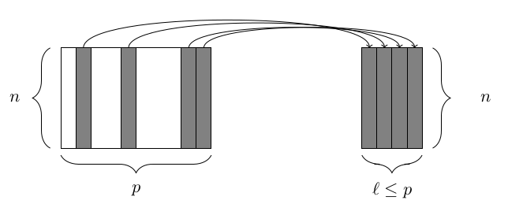

Схема роботи селекту

## filter()

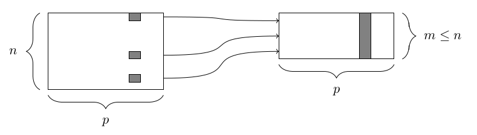

Схема роботи фільтрації

## Президентські вибори в Америці

```r
library(mdsr,warn.conflicts = F)
presidential
```

```
## # A tibble: 11 x 4
##    name       start      end        party
##    <chr>      <date>     <date>     <chr>
##  1 Eisenhower 1953-01-20 1961-01-20 Republican
##  2 Kennedy    1961-01-20 1963-11-22 Democratic
##  3 Johnson    1963-11-22 1969-01-20 Democratic
##  4 Nixon      1969-01-20 1974-08-09 Republican
##  5 Ford       1974-08-09 1977-01-20 Republican
##  6 Carter     1977-01-20 1981-01-20 Democratic
##  7 Reagan     1981-01-20 1989-01-20 Republican
##  8 Bush       1989-01-20 1993-01-20 Republican
##  9 Clinton    1993-01-20 2001-01-20 Democratic
## 10 Bush       2001-01-20 2009-01-20 Republican
## 11 Obama      2009-01-20 2017-01-20 Democratic
```

## Завдання.

1. Вибрати лише імена і партію
2. Вибрати дані лише республіканців
3. Вибрати всіх демократів після 1973 року
4. Додати термін повноважень кожного президента (в днях або іншому вимірі)
5. Додати рік обрання
6. Відсортувати президентів за терміном повноважень

## Вибрати лише імена і партію

```r
select(presidential, name, party)
```

```
## # A tibble: 11 x 2
##    name       party
##    <chr>      <chr>
##  1 Eisenhower Republican
##  2 Kennedy    Democratic
##  3 Johnson    Democratic
##  4 Nixon      Republican
##  5 Ford       Republican
##  6 Carter     Democratic
##  7 Reagan     Republican
##  8 Bush       Republican
##  9 Clinton    Democratic
## 10 Bush       Republican
## 11 Obama      Democratic
```

## Вибрати дані лише республіканців

```r
filter(presidential, party == "Republican")
```

```
## # A tibble: 6 x 4
##   name       start      end        party
##   <chr>      <date>     <date>     <chr>
## 1 Eisenhower 1953-01-20 1961-01-20 Republican
## 2 Nixon      1969-01-20 1974-08-09 Republican
## 3 Ford       1974-08-09 1977-01-20 Republican
## 4 Reagan     1981-01-20 1989-01-20 Republican
## 5 Bush       1989-01-20 1993-01-20 Republican
## 6 Bush       2001-01-20 2009-01-20 Republican
```

## Вибрати всіх демократів після 1973 року

```r
select(filter(presidential, start > 1973 & party == "Democratic"), name)
```

```
## # A tibble: 3 x 1
##   name
##   <chr>
## 1 Carter
## 2 Clinton
## 3 Obama
```

## Mutate()

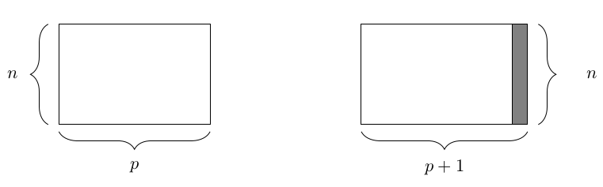

Схема роботи mutate()

## Створення труб pipeline operation

```r
presidential %>%
filter(start > 1973 & party == "Democratic") %>%
select(name)
```

```
## # A tibble: 3 x 1
##   name
##   <chr>
## 1 Carter
## 2 Clinton
## 3 Obama
```

Дозволяє створювати більш структурований код.

dataframe %>% filter(condition) це те саме, що filter(dataframe, condition)

## Додавання терміну повноважень

```r
library(lubridate, warn.conflicts = F)
mypresidents <- presidential %>%
mutate(term.length = interval(start, end) / dyears(1))
mypresidents
```

```
## # A tibble: 11 x 5
##    name       start      end        party      term.length
##    <chr>      <date>     <date>     <chr>            <dbl>
##  1 Eisenhower 1953-01-20 1961-01-20 Republican        8.01
##  2 Kennedy    1961-01-20 1963-11-22 Democratic        2.84
##  3 Johnson    1963-11-22 1969-01-20 Democratic        5.17
##  4 Nixon      1969-01-20 1974-08-09 Republican        5.55
##  5 Ford       1974-08-09 1977-01-20 Republican        2.45
##  6 Carter     1977-01-20 1981-01-20 Democratic        4.00
##  7 Reagan     1981-01-20 1989-01-20 Republican        8.01
##  8 Bush       1989-01-20 1993-01-20 Republican        4.00
##  9 Clinton    1993-01-20 2001-01-20 Democratic        8.01
## 10 Bush       2001-01-20 2009-01-20 Republican        8.01
## 11 Obama      2009-01-20 2017-01-20 Democratic        8.01
```

## Додати рік обрання

```r
mypresidents <- mypresidents %>% mutate(elected = year(start) - 1)
mypresidents
```

```
## # A tibble: 11 x 6
##    name       start      end        party      term.length elected
##    <chr>      <date>     <date>     <chr>            <dbl>   <dbl>
##  1 Eisenhower 1953-01-20 1961-01-20 Republican        8.01    1952
##  2 Kennedy    1961-01-20 1963-11-22 Democratic        2.84    1960
##  3 Johnson    1963-11-22 1969-01-20 Democratic        5.17    1962
##  4 Nixon      1969-01-20 1974-08-09 Republican        5.55    1968
##  5 Ford       1974-08-09 1977-01-20 Republican        2.45    1973
##  6 Carter     1977-01-20 1981-01-20 Democratic        4.00    1976
##  7 Reagan     1981-01-20 1989-01-20 Republican        8.01    1980
##  8 Bush       1989-01-20 1993-01-20 Republican        4.00    1988
##  9 Clinton    1993-01-20 2001-01-20 Democratic        8.01    1992
## 10 Bush       2001-01-20 2009-01-20 Republican        8.01    2000
## 11 Obama      2009-01-20 2017-01-20 Democratic        8.01    2008
```

## Але тут є неточність. Деяких президентів не обирали.

```r
mypresidents <- mypresidents %>%
mutate(elected = ifelse((elected %in% c(1962, 1973)), NA, elected))
mypresidents
```

```
## # A tibble: 11 x 6
##    name       start      end        party      term.length elected
##    <chr>      <date>     <date>     <chr>            <dbl>   <dbl>
##  1 Eisenhower 1953-01-20 1961-01-20 Republican        8.01    1952
##  2 Kennedy    1961-01-20 1963-11-22 Democratic        2.84    1960
##  3 Johnson    1963-11-22 1969-01-20 Democratic        5.17      NA
##  4 Nixon      1969-01-20 1974-08-09 Republican        5.55    1968
##  5 Ford       1974-08-09 1977-01-20 Republican        2.45      NA
##  6 Carter     1977-01-20 1981-01-20 Democratic        4.00    1976
##  7 Reagan     1981-01-20 1989-01-20 Republican        8.01    1980
##  8 Bush       1989-01-20 1993-01-20 Republican        4.00    1988
##  9 Clinton    1993-01-20 2001-01-20 Democratic        8.01    1992
## 10 Bush       2001-01-20 2009-01-20 Republican        8.01    2000
## 11 Obama      2009-01-20 2017-01-20 Democratic        8.01    2008
```

## Arrange()

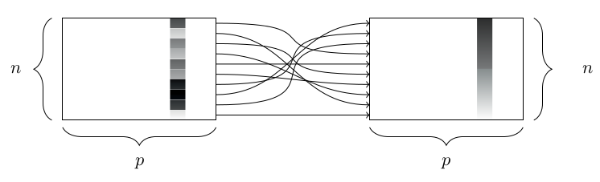

Схема роботи arrange()

## Відсортуємо президентів за терміном

```r
mypresidents %>% arrange(desc(term.length))
```

```
## # A tibble: 11 x 6
##    name       start      end        party      term.length elected
##    <chr>      <date>     <date>     <chr>            <dbl>   <dbl>
##  1 Eisenhower 1953-01-20 1961-01-20 Republican        8.01    1952
##  2 Reagan     1981-01-20 1989-01-20 Republican        8.01    1980
##  3 Clinton    1993-01-20 2001-01-20 Democratic        8.01    1992
##  4 Bush       2001-01-20 2009-01-20 Republican        8.01    2000
##  5 Obama      2009-01-20 2017-01-20 Democratic        8.01    2008
##  6 Nixon      1969-01-20 1974-08-09 Republican        5.55    1968
##  7 Johnson    1963-11-22 1969-01-20 Democratic        5.17      NA
##  8 Carter     1977-01-20 1981-01-20 Democratic        4.00    1976
##  9 Bush       1989-01-20 1993-01-20 Republican        4.00    1988
## 10 Kennedy    1961-01-20 1963-11-22 Democratic        2.84    1960
## 11 Ford       1974-08-09 1977-01-20 Republican        2.45      NA
```

## Відсортуємо за партією і роком обрання

```r
mypresidents %>% arrange(desc(term.length), party, elected)
```

```
## # A tibble: 11 x 6
##    name       start      end        party      term.length elected
##    <chr>      <date>     <date>     <chr>            <dbl>   <dbl>
##  1 Clinton    1993-01-20 2001-01-20 Democratic        8.01    1992
##  2 Obama      2009-01-20 2017-01-20 Democratic        8.01    2008
##  3 Eisenhower 1953-01-20 1961-01-20 Republican        8.01    1952
##  4 Reagan     1981-01-20 1989-01-20 Republican        8.01    1980
##  5 Bush       2001-01-20 2009-01-20 Republican        8.01    2000
##  6 Nixon      1969-01-20 1974-08-09 Republican        5.55    1968
##  7 Johnson    1963-11-22 1969-01-20 Democratic        5.17      NA
##  8 Carter     1977-01-20 1981-01-20 Democratic        4.00    1976
##  9 Bush       1989-01-20 1993-01-20 Republican        4.00    1988
## 10 Kennedy    1961-01-20 1963-11-22 Democratic        2.84    1960
## 11 Ford       1974-08-09 1977-01-20 Republican        2.45      NA
```

## Останні дві операції summarize() та group_by()

Якщо summarize() використовується окремо, датафрейм відображається в один рядок. Якщо додається group_by() - виникає можливість порівнювати.

```r
mypresidents %>%
  summarize(
    N = n(), first_year = min(year(start)), last_year = max(year(end)),
    num_dems = sum(party == "Democratic"),
    years = sum(term.length),
    avg_term_length = mean(term.length))
```

```
## # A tibble: 1 x 6
##       N first_year last_year num_dems years avg_term_length
##   <int>      <dbl>     <dbl>    <int> <dbl>           <dbl>
## 1    11       1953      2017        5  64.0            5.82
```

## Тепер додамо групування

```r
mypresidents %>%
  group_by(party) %>%
  summarize(
    N = n(), first_year = min(year(start)), last_year = max(year(end)),
    num_dems = sum(party == "Democratic"),
    years = sum(term.length),
    avg_term_length = mean(term.length))
```

```
## # A tibble: 2 x 7
##   party          N first_year last_year num_dems years avg_term_length
##   <chr>      <int>      <dbl>     <dbl>    <int> <dbl>           <dbl>
## 1 Democratic     5       1961      2017        5  28.0            5.60
## 2 Republican     6       1953      2009        0  36.0            6.00
```

## Додамо вік депутатів

```r
df1$birthday <- as.Date(df1$birthday, format="%d.%m.%Y")
df1 <- df1 %>%
  mutate(age  = 2019 - year(birthday))
```

## Завдання перша лабораторна.

1. Вибрати датасет.
2. Завантажити його в R.
3. Провести опис даних, визначити характеристики.
4. Створити по одному питанню з кожної категорії.
5. Використати всі операції dplyr() які розглядались.

## Джерело датасетів.

https://knoema.com/